# analisis_indicadores

# Creencias autoritarias

## PACES: estudiantes

### Descriptivo

```r
est_creencias_autoritarias=paces_est %>% dplyr::select(autorit1, autorit2, autorit3, autorit4, autorit5, autorit6, autorit7, autorit8, autorit9) %>% as.data.frame()

graf_creencias_autoritarias_est <- sjPlot::plot_likert(est_creencias_autoritarias,
  groups = NULL,
  groups.titles = "auto",
  title = "¿Qué tan de acuerdo o en desacuerdo estás con las siguientes afirmaciones sobre los gobiernos y sus líderes?",
  legend.title = NULL,
  legend.labels = c("Muy en desacuerdo", "En desacuerdo", "De acuerdo", "Muy de acuerdo"),
  axis.titles = NULL,
  axis.labels = NULL,
  catcount = 4,
  cat.neutral = NULL,
  sort.frq = NULL,
  weight.by = paces_est$pond_estudiante_reg_dep_tens,
  title.wtd.suffix = NULL,
  wrap.title = 55,
  wrap.labels = 36,
  geom.size = 0.8,
  geom.colors ="Purples",
  reverse.colors = FALSE,
  values = "sum.outside",
  show.n = F,
  show.legend = TRUE,
  show.prc.sign = T,
  grid.range = 1.2,
  grid.breaks = 0.5,
  expand.grid = FALSE,
  digits = 0,
  reverse.scale = TRUE,
  coord.flip = TRUE,
  sort.groups = TRUE,
  rel_heights = 1,
  group.legend.options = list(nrow = NULL, byrow = TRUE),
  cowplot.options = list(label_x = 0.01, hjust = 0.5, vjust=0.5, align = "v")) + theme_bw() + theme(plot.title = element_text(size=14, face = "bold", hjust=0.5),
                      axis.text.y = element_text(size=10, face = "bold"), legend.position = "bottom", legend.text = element_text(size=10, face="bold"))

ggsave(graf_creencias_autoritarias_est, file = "../output/creencias_autoritarias_estudiantes.png",device = "png",width = 21,height = 18,dpi = "retina",units = "cm")
```

### Bivariado

```r
polychoric(est_creencias_autoritarias)
```

```
## Call: polychoric(x = est_creencias_autoritarias)
## Polychoric correlations
##          atrt1 atrt2 atrt3 atrt4 atrt5 atrt6 atrt7 atrt8 atrt9
## autorit1  1.00
## autorit2 -0.19  1.00
## autorit3  0.38  0.08  1.00
## autorit4  0.13  0.12 -0.21  1.00
## autorit5  0.48 -0.06  0.18  0.38  1.00
## autorit6  0.12  0.15 -0.18  0.45  0.33  1.00
## autorit7  0.37 -0.03  0.01  0.40  0.43  0.46  1.00
## autorit8  0.31 -0.02  0.06  0.33  0.39  0.38  0.61  1.00
## autorit9  0.29 -0.02  0.09  0.30  0.36  0.39  0.57  0.80  1.00
##
##  with tau of
##              1      2    3
## autorit1 -1.49 -0.839 0.70
## autorit2 -1.09  0.222 1.23
## autorit3 -1.99 -1.256 0.21
## autorit4  0.01  0.816 1.61
## autorit5 -1.24 -0.369 1.22
## autorit6 -0.53  0.505 1.40
## autorit7 -0.80  0.041 1.27
## autorit8 -0.96 -0.199 1.16
## autorit9 -1.02 -0.244 1.15
```

```r
png("../output/cor_creencias_autoritarias_est.png",width=600,height=600)
corrplot.mixed(cor(est_creencias_autoritarias, use = "na.or.complete", method="spearman"))
dev.off()
```

### Fiabilidad: alpha de cronbach

```r
alpha(est_creencias_autoritarias)
```

```
## Some items ( autorit2 ) were negatively correlated with the total scale and
## probably should be reversed.
## To do this, run the function again with the 'check.keys=TRUE' option
```

```
##
## Reliability analysis
## Call: alpha(x = est_creencias_autoritarias)
##
##   raw_alpha std.alpha G6(smc) average_r S/N  ase mean   sd median_r
##       0.71       0.7    0.75      0.21 2.3 0.01  2.5 0.48     0.25
##
##  lower alpha upper     95% confidence boundaries
## 0.69 0.71 0.73
##
##  Reliability if an item is dropped:
##          raw_alpha std.alpha G6(smc) average_r S/N alpha se var.r med.r
## autorit1      0.69      0.68    0.72      0.21 2.1   0.0109 0.045  0.25
## autorit2      0.75      0.74    0.77      0.26 2.9   0.0090 0.035  0.30
## autorit3      0.73      0.73    0.75      0.25 2.7   0.0097 0.038  0.28
## autorit4      0.69      0.68    0.73      0.21 2.1   0.0110 0.046  0.25
## autorit5      0.67      0.65    0.71      0.19 1.9   0.0118 0.046  0.19
## autorit6      0.68      0.67    0.72      0.20 2.0   0.0116 0.045  0.24
## autorit7      0.65      0.64    0.69      0.18 1.8   0.0128 0.038  0.20
## autorit8      0.64      0.63    0.67      0.18 1.7   0.0130 0.033  0.20
## autorit9      0.65      0.64    0.67      0.18 1.7   0.0128 0.035  0.21
##
##  Item statistics
##             n raw.r std.r r.cor r.drop mean   sd
## autorit1 1575  0.51  0.53 0.447  0.346  3.0 0.80
## autorit2 1563  0.22  0.22 0.035  0.014  2.4 0.85
## autorit3 1560  0.25  0.29 0.149  0.084  3.3 0.71
## autorit4 1559  0.54  0.52 0.422  0.363  1.8 0.90
## autorit5 1545  0.62  0.63 0.561  0.477  2.6 0.82
## autorit6 1548  0.60  0.58 0.499  0.433  2.1 0.92
## autorit7 1528  0.71  0.70 0.669  0.579  2.4 0.93
## autorit8 1513  0.73  0.72 0.731  0.603  2.5 0.91
## autorit9 1511  0.71  0.70 0.708  0.582  2.6 0.90
##
## Non missing response frequency for each item
##             1    2    3    4 miss
## autorit1 0.07 0.13 0.56 0.24 0.04
## autorit2 0.14 0.45 0.30 0.11 0.04
## autorit3 0.02 0.08 0.48 0.42 0.05
## autorit4 0.50 0.29 0.15 0.05 0.05
## autorit5 0.11 0.25 0.53 0.11 0.06
## autorit6 0.30 0.39 0.23 0.08 0.05
## autorit7 0.21 0.30 0.38 0.10 0.07
## autorit8 0.17 0.25 0.46 0.12 0.07
## autorit9 0.15 0.25 0.47 0.13 0.08
```

### Validez modelo de medida

```r
cfa_1 <- 'c_autoritarias =~ autorit1 + autorit2 + autorit3 + autorit4 + autorit5 + autorit6 + autorit7 + autorit8 + autorit9'
fit_1 <- cfa(cfa_1,data=est_creencias_autoritarias,estimator="DWLS")
show(fit_1) # Resumen ajuste general
```

```
## lavaan 0.6-7 ended normally after 35 iterations
##
##   Estimator                                       DWLS
##   Optimization method                           NLMINB
##   Number of free parameters                         18
##
##                                                   Used       Total
##   Number of observations                          1432        1635
##
## Model Test User Model:
##
##   Test statistic                               365.642
##   Degrees of freedom                                27
##   P-value (Chi-square)                           0.000
```

```r
fitMeasures(fit_1, c("chisq", "df", "pvalue", "cfi", "tli", "rmsea"))
```

```
##   chisq      df  pvalue     cfi     tli   rmsea
## 365.642  27.000   0.000   0.898   0.864   0.094
```

```r
summary(fit_1, fit.measures=T, standardized=T)
```

```
## lavaan 0.6-7 ended normally after 35 iterations
##
##   Estimator                                       DWLS
##   Optimization method                           NLMINB
##   Number of free parameters                         18
##
##                                                   Used       Total
##   Number of observations                          1432        1635
##
## Model Test User Model:
##
##   Test statistic                               365.642
##   Degrees of freedom                                27
##   P-value (Chi-square)                           0.000
##
## Model Test Baseline Model:
##
##   Test statistic                              3359.088
##   Degrees of freedom                                36
##   P-value                                        0.000
##
## User Model versus Baseline Model:
##
##   Comparative Fit Index (CFI)                    0.898
##   Tucker-Lewis Index (TLI)                       0.864
##
## Root Mean Square Error of Approximation:
##
##   RMSEA                                          0.094
##   90 Percent confidence interval - lower         0.085
##   90 Percent confidence interval - upper         0.102
##   P-value RMSEA <= 0.05                          0.000
##
## Standardized Root Mean Square Residual:
##
##   SRMR                                           0.090
##
## Parameter Estimates:
##
##   Standard errors                             Standard
```

[output cut: 13 more lines]

```
##     autorit8           2.205    0.133   16.536    0.000    0.703    0.771
##     autorit9           2.092    0.127   16.473    0.000    0.667    0.745
##
## Variances:
##                    Estimate  Std.Err  z-value  P(>|z|)   Std.lv  Std.all
##    .autorit1          0.549    0.028   19.276    0.000    0.549    0.844
##    .autorit2          0.731    0.023   31.412    0.000    0.731    1.000
##    .autorit3          0.510    0.023   22.511    0.000    0.510    0.996
##    .autorit4          0.662    0.032   20.687    0.000    0.662    0.822
##    .autorit5          0.479    0.028   17.390    0.000    0.479    0.720
##    .autorit6          0.645    0.031   20.768    0.000    0.645    0.753
##    .autorit7          0.419    0.037   11.425    0.000    0.419    0.482
##    .autorit8          0.338    0.039    8.730    0.000    0.338    0.406
##    .autorit9          0.357    0.037    9.698    0.000    0.357    0.445
##     c_autoritarias    0.102    0.010    9.984    0.000    1.000    1.000
```

```r
modificationindices(fit_1)
```

```
##         lhs op      rhs     mi    epc sepc.lv sepc.all sepc.nox
## 20 autorit1 ~~ autorit2 25.476 -0.115  -0.115   -0.182   -0.182
## 21 autorit1 ~~ autorit3 71.993  0.181   0.181    0.343    0.343
## 22 autorit1 ~~ autorit4  4.649 -0.050  -0.050   -0.083   -0.083
## 23 autorit1 ~~ autorit5 49.941  0.162   0.162    0.316    0.316
## 24 autorit1 ~~ autorit6  9.329 -0.072  -0.072   -0.121   -0.121
## 25 autorit1 ~~ autorit7  1.349  0.031   0.031    0.064    0.064
## 26 autorit1 ~~ autorit8  3.079 -0.047  -0.047   -0.110   -0.110
## 27 autorit1 ~~ autorit9  2.432 -0.041  -0.041   -0.092   -0.092
## 28 autorit2 ~~ autorit3  7.946  0.050   0.050    0.082    0.082
## 29 autorit2 ~~ autorit4 13.835  0.089   0.089    0.127    0.127
## 30 autorit2 ~~ autorit5  3.070 -0.041  -0.041   -0.070   -0.070
## 31 autorit2 ~~ autorit6 22.026  0.119   0.119    0.174    0.174
## 32 autorit2 ~~ autorit7  0.656 -0.022  -0.022   -0.040   -0.040
## 33 autorit2 ~~ autorit8  0.311 -0.015  -0.015   -0.031   -0.031
```

[output cut: 22 more lines]

```r
# Debido a que el modelo no presentaba un ajuste adecuado, solicite los indices de modificación. La mayoría de las sugerencias hacía referencia al indicador 1 y al indicador 9, por lo que se probaron los modelos eliminando 1 de estos dos indicadores, y eliminando los dos indicadores.

### Este modelo no convergió
#cfa_2 <- 'c_autoritarias =~ autorit2 + autorit3 + autorit4 + autorit5 + autorit6 + autorit7 + autorit8 + autorit9'
#fit_2 <- cfa(cfa_2,data=est_creencias_autoritarias,estimator="DWLS")
#show(fit_2) # Resumen ajuste general
#fitMeasures(fit_2, c("chisq", "df", "pvalue", "cfi", "tli", "rmsea"))
#summary(fit_2, fit.measures=T, standardized=T)

cfa_3 <- 'c_autoritarias =~ autorit1 + autorit2 + autorit3 + autorit4 + autorit5 + autorit6 + autorit7 + autorit8'
fit_3 <- cfa(cfa_3,data=est_creencias_autoritarias,estimator="DWLS")
show(fit_3) # Resumen ajuste general
```

```
## lavaan 0.6-7 ended normally after 33 iterations
##
##   Estimator                                       DWLS
##   Optimization method                           NLMINB
##   Number of free parameters                         16
##
##                                                   Used       Total
##   Number of observations                          1440        1635
##
## Model Test User Model:
##
##   Test statistic                               303.891
##   Degrees of freedom                                20
##   P-value (Chi-square)                           0.000
```

```r
fitMeasures(fit_3, c("chisq", "df", "pvalue", "cfi", "tli", "rmsea"))
```

```
##   chisq      df  pvalue     cfi     tli   rmsea
## 303.891  20.000   0.000   0.863   0.808   0.099
```

```r
summary(fit_3, fit.measures=T, standardized=T)
```

```
## lavaan 0.6-7 ended normally after 33 iterations
##
##   Estimator                                       DWLS
##   Optimization method                           NLMINB
##   Number of free parameters                         16
##
##                                                   Used       Total
##   Number of observations                          1440        1635
##
## Model Test User Model:
##
##   Test statistic                               303.891
##   Degrees of freedom                                20
##   P-value (Chi-square)                           0.000
##
## Model Test Baseline Model:
##
##   Test statistic                              2102.395
##   Degrees of freedom                                28
##   P-value                                        0.000
##
## User Model versus Baseline Model:
##
##   Comparative Fit Index (CFI)                    0.863
##   Tucker-Lewis Index (TLI)                       0.808
##
## Root Mean Square Error of Approximation:
##
##   RMSEA                                          0.099
##   90 Percent confidence interval - lower         0.090
##   90 Percent confidence interval - upper         0.109
##   P-value RMSEA <= 0.05                          0.000
##
## Standardized Root Mean Square Residual:
##
##   SRMR                                           0.092
##
## Parameter Estimates:
##
##   Standard errors                             Standard
```

[output cut: 11 more lines]

```
##     autorit6           1.419    0.104   13.613    0.000    0.480    0.517
##     autorit7           2.039    0.142   14.317    0.000    0.689    0.738
##     autorit8           1.762    0.123   14.315    0.000    0.596    0.652
##
## Variances:
##                    Estimate  Std.Err  z-value  P(>|z|)   Std.lv  Std.all
##    .autorit1          0.536    0.029   18.288    0.000    0.536    0.824
##    .autorit2          0.735    0.023   31.581    0.000    0.735    1.000
##    .autorit3          0.509    0.023   22.577    0.000    0.509    0.997
##    .autorit4          0.635    0.034   18.793    0.000    0.635    0.787
##    .autorit5          0.440    0.030   14.486    0.000    0.440    0.660
##    .autorit6          0.631    0.033   18.868    0.000    0.631    0.733
##    .autorit7          0.398    0.043    9.343    0.000    0.398    0.456
##    .autorit8          0.481    0.037   12.935    0.000    0.481    0.575
##     c_autoritarias    0.114    0.012    9.152    0.000    1.000    1.000
```

```r
modificationindices(fit_3)
```

```
##         lhs op      rhs     mi    epc sepc.lv sepc.all sepc.nox
## 18 autorit1 ~~ autorit2 27.779 -0.122  -0.122   -0.194   -0.194
## 19 autorit1 ~~ autorit3 75.049  0.186   0.186    0.356    0.356
## 20 autorit1 ~~ autorit4 11.122 -0.081  -0.081   -0.139   -0.139
## 21 autorit1 ~~ autorit5 40.487  0.156   0.156    0.321    0.321
## 22 autorit1 ~~ autorit6 16.904 -0.102  -0.102   -0.176   -0.176
## 23 autorit1 ~~ autorit7  0.100  0.009   0.009    0.020    0.020
## 24 autorit1 ~~ autorit8  0.187 -0.012  -0.012   -0.023   -0.023
## 25 autorit2 ~~ autorit3  7.574  0.049   0.049    0.080    0.080
## 26 autorit2 ~~ autorit4 14.929  0.094   0.094    0.138    0.138
## 27 autorit2 ~~ autorit5  4.158 -0.050  -0.050   -0.087   -0.087
## 28 autorit2 ~~ autorit6 23.860  0.128   0.128    0.187    0.187
## 29 autorit2 ~~ autorit7  1.331 -0.033  -0.033   -0.061   -0.061
## 30 autorit2 ~~ autorit8  0.552 -0.020  -0.020   -0.034   -0.034
## 31 autorit3 ~~ autorit4 35.123 -0.112  -0.112   -0.198   -0.198
## 32 autorit3 ~~ autorit5 23.423  0.100   0.100    0.210    0.210
## 33 autorit3 ~~ autorit6 31.121 -0.112  -0.112   -0.198   -0.198
## 34 autorit3 ~~ autorit7  0.183 -0.010  -0.010   -0.021   -0.021
## 35 autorit3 ~~ autorit8  1.004  0.022   0.022    0.045    0.045
## 36 autorit4 ~~ autorit5  1.582  0.033   0.033    0.062    0.062
## 37 autorit4 ~~ autorit6 26.538  0.151   0.151    0.239    0.239
## 38 autorit4 ~~ autorit7  1.268 -0.038  -0.038   -0.075   -0.075
## 39 autorit4 ~~ autorit8  1.773 -0.040  -0.040   -0.072   -0.072
## 40 autorit5 ~~ autorit6  0.946 -0.028  -0.028   -0.052   -0.052
## 41 autorit5 ~~ autorit7 10.167 -0.109  -0.109   -0.261   -0.261
## 42 autorit5 ~~ autorit8  3.491 -0.059  -0.059   -0.128   -0.128
## 43 autorit6 ~~ autorit7  0.468  0.025   0.025    0.049    0.049
## 44 autorit6 ~~ autorit8  0.046 -0.007  -0.007   -0.013   -0.013
## 45 autorit7 ~~ autorit8  9.988  0.128   0.128    0.293    0.293
```

```r
cfa_4 <- 'c_autoritarias =~ autorit2 + autorit3 + autorit4 + autorit5 + autorit6 + autorit7 + autorit8'
fit_4 <- cfa(cfa_4,data=est_creencias_autoritarias,estimator="DWLS")
show(fit_4) # Resumen ajuste general
```

```
## lavaan 0.6-7 ended normally after 154 iterations
##
##   Estimator                                       DWLS
##   Optimization method                           NLMINB
##   Number of free parameters                         14
##
##                                                   Used       Total
##   Number of observations                          1444        1635
##
## Model Test User Model:
##
##   Test statistic                               140.446
##   Degrees of freedom                                14
##   P-value (Chi-square)                           0.000
```

```r
fitMeasures(fit_4, c("chisq", "df", "pvalue", "cfi", "tli", "rmsea"))
```

```
##   chisq      df  pvalue     cfi     tli   rmsea
## 140.446  14.000   0.000   0.920   0.880   0.079
```

```r
summary(fit_4, fit.measures=T, standardized=T)
```

```
## lavaan 0.6-7 ended normally after 154 iterations
##
##   Estimator                                       DWLS
##   Optimization method                           NLMINB
##   Number of free parameters                         14
##
##                                                   Used       Total
##   Number of observations                          1444        1635
##
## Model Test User Model:
##
##   Test statistic                               140.446
##   Degrees of freedom                                14
##   P-value (Chi-square)                           0.000
##
## Model Test Baseline Model:
##
##   Test statistic                              1602.265
##   Degrees of freedom                                21
##   P-value                                        0.000
##
## User Model versus Baseline Model:
##
##   Comparative Fit Index (CFI)                    0.920
##   Tucker-Lewis Index (TLI)                       0.880
##
## Root Mean Square Error of Approximation:
##
##   RMSEA                                          0.079
##   90 Percent confidence interval - lower         0.068
##   90 Percent confidence interval - upper         0.091
##   P-value RMSEA <= 0.05                          0.000
##
## Standardized Root Mean Square Residual:
##
##   SRMR                                           0.067
##
## Parameter Estimates:
##
##   Standard errors                             Standard
```

[output cut: 9 more lines]

```
##     autorit5          11.073    5.699    1.943    0.052    0.424    0.520
##     autorit6          13.802    7.099    1.944    0.052    0.528    0.570
##     autorit7          17.731    9.116    1.945    0.052    0.679    0.727
##     autorit8          15.378    7.906    1.945    0.052    0.589    0.645
##
## Variances:
##                    Estimate  Std.Err  z-value  P(>|z|)   Std.lv  Std.all
##    .autorit2          0.732    0.023   31.493    0.000    0.732    0.998
##    .autorit3          0.511    0.022   22.732    0.000    0.511    1.000
##    .autorit4          0.606    0.035   17.193    0.000    0.606    0.749
##    .autorit5          0.486    0.029   16.653    0.000    0.486    0.730
##    .autorit6          0.581    0.036   15.979    0.000    0.581    0.676
##    .autorit7          0.411    0.044    9.282    0.000    0.411    0.471
##    .autorit8          0.487    0.038   12.746    0.000    0.487    0.584
##     c_autoritarias    0.001    0.002    0.977    0.329    1.000    1.000
```

```r
modificationindices(fit_4)
```

```
##         lhs op      rhs     mi    epc sepc.lv sepc.all sepc.nox
## 16 autorit2 ~~ autorit3  7.770  0.049   0.049    0.080    0.080
## 17 autorit2 ~~ autorit4 10.455  0.080   0.080    0.121    0.121
## 18 autorit2 ~~ autorit5  7.408 -0.065  -0.065   -0.110   -0.110
## 19 autorit2 ~~ autorit6 17.356  0.112   0.112    0.171    0.171
## 20 autorit2 ~~ autorit7  5.656 -0.069  -0.069   -0.126   -0.126
## 21 autorit2 ~~ autorit8  2.891 -0.047  -0.047   -0.078   -0.078
## 22 autorit3 ~~ autorit4 25.226 -0.097  -0.097   -0.174   -0.174
## 23 autorit3 ~~ autorit5 33.970  0.118   0.118    0.236    0.236
## 24 autorit3 ~~ autorit6 20.069 -0.092  -0.092   -0.169   -0.169
## 25 autorit3 ~~ autorit7  1.749  0.030   0.030    0.065    0.065
## 26 autorit3 ~~ autorit8  5.921  0.054   0.054    0.108    0.108
## 27 autorit4 ~~ autorit5  2.886  0.045   0.045    0.083    0.083
## 28 autorit4 ~~ autorit6 12.911  0.114   0.114    0.192    0.192
## 29 autorit4 ~~ autorit7  6.028 -0.089  -0.089   -0.178   -0.178
## 30 autorit4 ~~ autorit8  6.520 -0.082  -0.082   -0.151   -0.151
## 31 autorit5 ~~ autorit6  0.575 -0.022  -0.022   -0.042   -0.042
## 32 autorit5 ~~ autorit7  0.348 -0.020  -0.020   -0.045   -0.045
## 33 autorit5 ~~ autorit8  0.016  0.004   0.004    0.008    0.008
## 34 autorit6 ~~ autorit7  1.072 -0.042  -0.042   -0.085   -0.085
## 35 autorit6 ~~ autorit8  3.216 -0.064  -0.064   -0.121   -0.121
## 36 autorit7 ~~ autorit8 16.638  0.178   0.178    0.398    0.398
```

```r
#Ninguno de los 4 modelos analizados presenta un ajuste adecuado. Por lo tanto, volví a revisar las correlaciones y me di cuenta de que sólo hay 3 indicadores con una correlación superior a 0.5 entre sí, por lo que decidí probar un modelo con sólo esos indicadores.

cfa_5 <- 'c_autoritarias =~ autorit7 + autorit8 + autorit9'
fit_5 <- cfa(cfa_5,data=est_creencias_autoritarias,estimator="DWLS")
show(fit_5) # Resumen ajuste general
```

```
## lavaan 0.6-7 ended normally after 20 iterations
##
##   Estimator                                       DWLS
##   Optimization method                           NLMINB
##   Number of free parameters                          6
##
##                                                   Used       Total
##   Number of observations                          1484        1635
##
## Model Test User Model:
##
##   Test statistic                                 0.000
##   Degrees of freedom                                 0
```

```r
fitMeasures(fit_5, c("chisq", "df", "pvalue", "cfi", "tli", "rmsea"))
```

```
##  chisq     df pvalue    cfi    tli  rmsea
##      0      0     NA      1      1      0
```

```r
summary(fit_5, fit.measures=T, standardized=T)
```

```
## lavaan 0.6-7 ended normally after 20 iterations
##
##   Estimator                                       DWLS
##   Optimization method                           NLMINB
##   Number of free parameters                          6
##
##                                                   Used       Total
##   Number of observations                          1484        1635
##
## Model Test User Model:
##
##   Test statistic                                 0.000
##   Degrees of freedom                                 0
##
## Model Test Baseline Model:
##
##   Test statistic                              1238.808
##   Degrees of freedom                                 3
##   P-value                                        0.000
##
## User Model versus Baseline Model:
##
##   Comparative Fit Index (CFI)                    1.000
##   Tucker-Lewis Index (TLI)                       1.000
##
## Root Mean Square Error of Approximation:
##
##   RMSEA                                          0.000
##   90 Percent confidence interval - lower         0.000
##   90 Percent confidence interval - upper         0.000
##   P-value RMSEA <= 0.05                             NA
##
## Standardized Root Mean Square Residual:
##
##   SRMR                                           0.000
##
## Parameter Estimates:
##
##   Standard errors                             Standard
##   Information                                 Expected
##   Information saturated (h1) model        Unstructured
##
## Latent Variables:
##                     Estimate  Std.Err  z-value  P(>|z|)   Std.lv  Std.all
##   c_autoritarias =~
##     autorit7           1.000                               0.565    0.607
##     autorit8           1.432    0.101   14.119    0.000    0.809    0.887
##     autorit9           1.317    0.089   14.807    0.000    0.744    0.831
##
## Variances:
##                    Estimate  Std.Err  z-value  P(>|z|)   Std.lv  Std.all
##    .autorit7          0.548    0.037   14.976    0.000    0.548    0.632
##    .autorit8          0.177    0.063    2.817    0.005    0.177    0.213
##    .autorit9          0.247    0.055    4.528    0.000    0.247    0.309
##     c_autoritarias    0.319    0.028   11.270    0.000    1.000    1.000
```

## PACES: apoderados

### Descriptivo

```r
apod_creencias_autoritarias=paces_apod %>% dplyr::select(autorit1, autorit2, autorit3, autorit4, autorit5, autorit6, autorit7, autorit8, autorit9) %>% as.data.frame()

graf_creencias_autoritarias_apod <- plot_likert(apod_creencias_autoritarias,
  groups = NULL,
  groups.titles = "auto",
  title = "¿Cuán de acuerdo o en desacuerdo está usted con las siguientes afirmaciones sobre los gobiernos y sus líderes?",
  legend.title = NULL,
  legend.labels = c("Muy en desacuerdo", "En desacuerdo", "De acuerdo", "Muy de acuerdo"),
  axis.titles = NULL,
  axis.labels = NULL,
  catcount = 4,
  cat.neutral = NULL,
  sort.frq = NULL,
  weight.by = paces_apod$pond_apoderado_reg_dep_tens,
  title.wtd.suffix = NULL,
  wrap.title = 55,
  wrap.labels = 36,
  geom.size = 0.8,
  geom.colors ="Purples",
  reverse.colors = FALSE,
  values = "sum.outside",
  show.n = F,
  show.legend = TRUE,
  show.prc.sign = T,
  grid.range = 1.2,
  grid.breaks = 0.5,
  expand.grid = FALSE,
  digits = 0,
  reverse.scale = TRUE,
  coord.flip = TRUE,
  sort.groups = TRUE,
  rel_heights = 1,
  group.legend.options = list(nrow = NULL, byrow = TRUE),
  cowplot.options = list(label_x = 0.01, hjust = 0.5, vjust=0.5, align = "v")) + theme_bw() + theme(plot.title = element_text(size=14, face = "bold", hjust=0.5),
  axis.text.y = element_text(size=10, face = "bold"), legend.position = "bottom", legend.text = element_text(size=10, face="bold"))

ggsave(graf_creencias_autoritarias_apod, file = "../output/creencias_autoritarias_apoderados.png",device = "png",width = 21,height = 18,dpi = "retina",units = "cm")
```

### Bivariado

```r
polychoric(apod_creencias_autoritarias)
```

```
## Call: polychoric(x = apod_creencias_autoritarias)
## Polychoric correlations
##          atrt1 atrt2 atrt3 atrt4 atrt5 atrt6 atrt7 atrt8 atrt9
## autorit1  1.00
## autorit2 -0.36  1.00
## autorit3  0.25  0.02  1.00
## autorit4  0.13 -0.02 -0.17  1.00
## autorit5  0.43 -0.12  0.18  0.39  1.00
## autorit6 -0.03  0.03 -0.26  0.33  0.28  1.00
## autorit7  0.30 -0.04 -0.13  0.33  0.44  0.48  1.00
## autorit8  0.26 -0.14 -0.09  0.28  0.40  0.39  0.64  1.00
## autorit9  0.17 -0.06 -0.20  0.30  0.37  0.38  0.65  0.80  1.00
##
##  with tau of
##               1     2    3
## autorit1 -2.065 -1.42 0.17
## autorit2 -0.788  0.49 1.41
## autorit3 -2.093 -1.47 0.16
## autorit4 -0.035  1.03 1.95
## autorit5 -1.140 -0.50 1.13
## autorit6 -0.301  0.82 1.58
## autorit7 -0.582  0.30 1.46
## autorit8 -0.628  0.14 1.35
## autorit9 -0.591  0.21 1.44
```

```r
png("../output/cor_creencias_autoritarias_apod.png",width=600,height=600)
corrplot.mixed(cor(apod_creencias_autoritarias, use = "na.or.complete", method="spearman"))
dev.off()
```

### Fiabilidad: alpha de cronbach

```r
alpha(apod_creencias_autoritarias)
```

```
## Some items ( autorit2 autorit3 ) were negatively correlated with the total scale and
## probably should be reversed.
## To do this, run the function again with the 'check.keys=TRUE' option
```

```
##
## Reliability analysis
## Call: alpha(x = apod_creencias_autoritarias)
##
##   raw_alpha std.alpha G6(smc) average_r S/N   ase mean   sd median_r
##       0.65      0.62    0.69      0.15 1.6 0.018  2.4 0.44     0.18
##
##  lower alpha upper     95% confidence boundaries
## 0.61 0.65 0.68
##
##  Reliability if an item is dropped:
##          raw_alpha std.alpha G6(smc) average_r S/N alpha se var.r med.r
## autorit1      0.64      0.61    0.67      0.16 1.6    0.018 0.061  0.23
## autorit2      0.72      0.69    0.73      0.22 2.2    0.015 0.049  0.24
## autorit3      0.69      0.68    0.72      0.21 2.1    0.016 0.052  0.24
## autorit4      0.62      0.59    0.67      0.15 1.4    0.019 0.065  0.15
## autorit5      0.59      0.54    0.63      0.13 1.2    0.021 0.061  0.12
## autorit6      0.61      0.58    0.66      0.15 1.4    0.020 0.060  0.15
## autorit7      0.54      0.51    0.60      0.12 1.0    0.024 0.048  0.13
## autorit8      0.55      0.52    0.58      0.12 1.1    0.024 0.043  0.13
## autorit9      0.55      0.53    0.59      0.12 1.1    0.023 0.043  0.14
##
##  Item statistics
##            n raw.r std.r  r.cor r.drop mean   sd
## autorit1 719 0.367 0.423  0.300  0.209  3.3 0.68
## autorit2 706 0.101 0.098 -0.125 -0.117  2.2 0.86
## autorit3 715 0.086 0.150 -0.056 -0.087  3.3 0.67
## autorit4 710 0.498 0.505  0.380  0.319  1.7 0.79
## autorit5 700 0.642 0.650  0.592  0.475  2.7 0.85
## autorit6 718 0.541 0.520  0.419  0.355  1.9 0.86
## autorit7 696 0.753 0.729  0.732  0.616  2.2 0.92
## autorit8 702 0.742 0.710  0.746  0.595  2.3 0.95
## autorit9 703 0.726 0.687  0.718  0.574  2.2 0.94
##
## Non missing response frequency for each item
##             1    2    3    4 miss
## autorit1 0.02 0.06 0.49 0.43 0.03
## autorit2 0.22 0.47 0.23 0.08 0.05
## autorit3 0.02 0.05 0.49 0.44 0.04
## autorit4 0.49 0.36 0.13 0.03 0.05
## autorit5 0.13 0.18 0.56 0.13 0.06
## autorit6 0.38 0.41 0.15 0.06 0.03
## autorit7 0.28 0.34 0.31 0.07 0.06
## autorit8 0.26 0.29 0.36 0.09 0.06
## autorit9 0.28 0.31 0.34 0.08 0.06
```

### Validez modelo de medida

```r
cfa_1 <- 'c_autoritarias =~ autorit1 + autorit2 + autorit3 + autorit4 + autorit5 + autorit6 + autorit7 + autorit8 + autorit9'
fit_1 <- cfa(cfa_1,data=apod_creencias_autoritarias,estimator="DWLS")
show(fit_1) # Resumen ajuste general
```

```
## lavaan 0.6-7 ended normally after 52 iterations
##
##   Estimator                                       DWLS
##   Optimization method                           NLMINB
##   Number of free parameters                         18
##
##                                                   Used       Total
##   Number of observations                           657         744
##
## Model Test User Model:
##
##   Test statistic                               163.787
##   Degrees of freedom                                27
##   P-value (Chi-square)                           0.000
```

```r
fitMeasures(fit_1, c("chisq", "df", "pvalue", "cfi", "tli", "rmsea"))
```

```
##   chisq      df  pvalue     cfi     tli   rmsea
## 163.787  27.000   0.000   0.903   0.870   0.088
```

```r
summary(fit_1, fit.measures=T, standardized=T)
```

```
## lavaan 0.6-7 ended normally after 52 iterations
##
##   Estimator                                       DWLS
##   Optimization method                           NLMINB
##   Number of free parameters                         18
##
##                                                   Used       Total
##   Number of observations                           657         744
##
## Model Test User Model:
##
##   Test statistic                               163.787
##   Degrees of freedom                                27
##   P-value (Chi-square)                           0.000
##
## Model Test Baseline Model:
##
##   Test statistic                              1441.842
##   Degrees of freedom                                36
##   P-value                                        0.000
##
## User Model versus Baseline Model:
##
##   Comparative Fit Index (CFI)                    0.903
##   Tucker-Lewis Index (TLI)                       0.870
##
## Root Mean Square Error of Approximation:
##
##   RMSEA                                          0.088
##   90 Percent confidence interval - lower         0.075
##   90 Percent confidence interval - upper         0.101
##   P-value RMSEA <= 0.05                          0.000
##
## Standardized Root Mean Square Residual:
##
##   SRMR                                           0.083
##
## Parameter Estimates:
##
##   Standard errors                             Standard
```

[output cut: 13 more lines]

```
##     autorit8           4.128    0.486    8.487    0.000    0.747    0.792
##     autorit9           3.971    0.467    8.502    0.000    0.719    0.778
##
## Variances:
##                    Estimate  Std.Err  z-value  P(>|z|)   Std.lv  Std.all
##    .autorit1          0.430    0.032   13.289    0.000    0.430    0.929
##    .autorit2          0.721    0.036   19.973    0.000    0.721    0.990
##    .autorit3          0.446    0.032   14.031    0.000    0.446    0.986
##    .autorit4          0.546    0.039   14.093    0.000    0.546    0.857
##    .autorit5          0.556    0.043   12.951    0.000    0.556    0.777
##    .autorit6          0.621    0.045   13.816    0.000    0.621    0.815
##    .autorit7          0.391    0.054    7.280    0.000    0.391    0.466
##    .autorit8          0.331    0.060    5.468    0.000    0.331    0.372
##    .autorit9          0.337    0.057    5.900    0.000    0.337    0.395
##     c_autoritarias    0.033    0.007    4.677    0.000    1.000    1.000
```

```r
modificationindices(fit_1)
```

```
##         lhs op      rhs     mi    epc sepc.lv sepc.all sepc.nox
## 20 autorit1 ~~ autorit2 31.454 -0.151  -0.151   -0.272   -0.272
## 21 autorit1 ~~ autorit3 22.166  0.092   0.092    0.209    0.209
## 22 autorit1 ~~ autorit4  0.299  0.012   0.012    0.026    0.026
## 23 autorit1 ~~ autorit5 22.403  0.133   0.133    0.273    0.273
## 24 autorit1 ~~ autorit6  8.893 -0.077  -0.077   -0.148   -0.148
## 25 autorit1 ~~ autorit7  1.185  0.034   0.034    0.082    0.082
## 26 autorit1 ~~ autorit8  0.074 -0.009  -0.009   -0.024   -0.024
## 27 autorit1 ~~ autorit9  4.659 -0.071  -0.071   -0.187   -0.187
## 28 autorit2 ~~ autorit3  0.360  0.014   0.014    0.024    0.024
## 29 autorit2 ~~ autorit4  0.111  0.010   0.010    0.016    0.016
## 30 autorit2 ~~ autorit5  0.436 -0.023  -0.023   -0.036   -0.036
## 31 autorit2 ~~ autorit6  2.373  0.052   0.052    0.077    0.077
## 32 autorit2 ~~ autorit7  1.540  0.049   0.049    0.092    0.092
## 33 autorit2 ~~ autorit8  0.249 -0.020  -0.020   -0.042   -0.042
```

[output cut: 22 more lines]

```r
# Debido a que el modelo no presentaba un ajuste adecuado, solicite los indices de modificación. Al igual que con los datos de los estudiantes, la mayoría de las sugerencias hacía referencia al indicador 1 y al indicador 9, por lo que se probaron los modelos eliminando 1 de estos dos indicadores, y eliminando los dos indicadores.

cfa_2 <- 'c_autoritarias =~ autorit2 + autorit3 + autorit4 + autorit5 + autorit6 + autorit7 + autorit8 + autorit9'
fit_2 <- cfa(cfa_2,data=apod_creencias_autoritarias,estimator="DWLS")
show(fit_2) # Resumen ajuste general
```

```
## lavaan 0.6-7 ended normally after 79 iterations
##
##   Estimator                                       DWLS
##   Optimization method                           NLMINB
##   Number of free parameters                         16
##
##                                                   Used       Total
##   Number of observations                           661         744
##
## Model Test User Model:
##
##   Test statistic                                76.194
##   Degrees of freedom                                20
##   P-value (Chi-square)                           0.000
```

```r
fitMeasures(fit_2, c("chisq", "df", "pvalue", "cfi", "tli", "rmsea"))
```

```
##  chisq     df pvalue    cfi    tli  rmsea
## 76.194 20.000  0.000  0.956  0.939  0.065
```

```r
summary(fit_2, fit.measures=T, standardized=T)
```

```
## lavaan 0.6-7 ended normally after 79 iterations
##
##   Estimator                                       DWLS
##   Optimization method                           NLMINB
##   Number of free parameters                         16
##
##                                                   Used       Total
##   Number of observations                           661         744
##
## Model Test User Model:
##
##   Test statistic                                76.194
##   Degrees of freedom                                20
##   P-value (Chi-square)                           0.000
##
## Model Test Baseline Model:
##
##   Test statistic                              1311.338
##   Degrees of freedom                                28
##   P-value                                        0.000
##
## User Model versus Baseline Model:
##
##   Comparative Fit Index (CFI)                    0.956
##   Tucker-Lewis Index (TLI)                       0.939
##
## Root Mean Square Error of Approximation:
##
##   RMSEA                                          0.065
##   90 Percent confidence interval - lower         0.050
##   90 Percent confidence interval - upper         0.081
##   P-value RMSEA <= 0.05                          0.049
##
## Standardized Root Mean Square Residual:
##
##   SRMR                                           0.061
##
## Parameter Estimates:
##
##   Standard errors                             Standard
```

[output cut: 11 more lines]

```
##     autorit7          -8.347    2.615   -3.193    0.001   -0.663   -0.723
##     autorit8          -9.451    2.960   -3.193    0.001   -0.750   -0.795
##     autorit9          -9.289    2.908   -3.194    0.001   -0.738   -0.798
##
## Variances:
##                    Estimate  Std.Err  z-value  P(>|z|)   Std.lv  Std.all
##    .autorit2          0.735    0.036   20.215    0.000    0.735    0.991
##    .autorit3          0.442    0.032   13.907    0.000    0.442    0.978
##    .autorit4          0.547    0.039   14.153    0.000    0.547    0.858
##    .autorit5          0.577    0.043   13.549    0.000    0.577    0.797
##    .autorit6          0.604    0.046   13.284    0.000    0.604    0.794
##    .autorit7          0.401    0.054    7.480    0.000    0.401    0.477
##    .autorit8          0.328    0.061    5.368    0.000    0.328    0.368
##    .autorit9          0.311    0.059    5.272    0.000    0.311    0.364
##     c_autoritarias    0.006    0.004    1.618    0.106    1.000    1.000
```

```r
cfa_3 <- 'c_autoritarias =~ autorit1 + autorit2 + autorit3 + autorit4 + autorit5 + autorit6 + autorit7 + autorit8'
fit_3 <- cfa(cfa_3,data=apod_creencias_autoritarias,estimator="DWLS")
show(fit_3) # Resumen ajuste general
```

```
## lavaan 0.6-7 ended normally after 47 iterations
##
##   Estimator                                       DWLS
##   Optimization method                           NLMINB
##   Number of free parameters                         16
##
##                                                   Used       Total
##   Number of observations                           657         744
##
## Model Test User Model:
##
##   Test statistic                               129.134
##   Degrees of freedom                                20
##   P-value (Chi-square)                           0.000
```

```r
fitMeasures(fit_3, c("chisq", "df", "pvalue", "cfi", "tli", "rmsea"))
```

```
##   chisq      df  pvalue     cfi     tli   rmsea
## 129.134  20.000   0.000   0.860   0.804   0.091
```

```r
summary(fit_3, fit.measures=T, standardized=T)
```

```
## lavaan 0.6-7 ended normally after 47 iterations
##
##   Estimator                                       DWLS
##   Optimization method                           NLMINB
##   Number of free parameters                         16
##
##                                                   Used       Total
##   Number of observations                           657         744
##
## Model Test User Model:
##
##   Test statistic                               129.134
##   Degrees of freedom                                20
##   P-value (Chi-square)                           0.000
##
## Model Test Baseline Model:
##
##   Test statistic                               807.730
##   Degrees of freedom                                28
##   P-value                                        0.000
##
## User Model versus Baseline Model:
##
##   Comparative Fit Index (CFI)                    0.860
##   Tucker-Lewis Index (TLI)                       0.804
##
## Root Mean Square Error of Approximation:
##
##   RMSEA                                          0.091
##   90 Percent confidence interval - lower         0.077
##   90 Percent confidence interval - upper         0.107
##   P-value RMSEA <= 0.05                          0.000
##
## Standardized Root Mean Square Residual:
##
##   SRMR                                           0.082
##
## Parameter Estimates:
##
##   Standard errors                             Standard
```

[output cut: 11 more lines]

```
##     autorit6           1.818    0.248    7.338    0.000    0.391    0.448
##     autorit7           3.191    0.403    7.919    0.000    0.686    0.750
##     autorit8           2.910    0.365    7.977    0.000    0.626    0.664
##
## Variances:
##                    Estimate  Std.Err  z-value  P(>|z|)   Std.lv  Std.all
##    .autorit1          0.416    0.033   12.594    0.000    0.416    0.900
##    .autorit2          0.718    0.036   19.772    0.000    0.718    0.986
##    .autorit3          0.450    0.032   14.170    0.000    0.450    0.994
##    .autorit4          0.524    0.041   12.873    0.000    0.524    0.823
##    .autorit5          0.503    0.048   10.489    0.000    0.503    0.704
##    .autorit6          0.609    0.047   12.855    0.000    0.609    0.799
##    .autorit7          0.367    0.066    5.604    0.000    0.367    0.438
##    .autorit8          0.497    0.060    8.356    0.000    0.497    0.559
##     c_autoritarias    0.046    0.010    4.738    0.000    1.000    1.000
```

```r
cfa_4 <- 'c_autoritarias =~ autorit2 + autorit3 + autorit4 + autorit5 + autorit6 + autorit7 + autorit8'
fit_4 <- cfa(cfa_4,data=apod_creencias_autoritarias,estimator="DWLS")
show(fit_4) # Resumen ajuste general
```

```
## lavaan 0.6-7 ended normally after 71 iterations
##
##   Estimator                                       DWLS
##   Optimization method                           NLMINB
##   Number of free parameters                         14
##
##                                                   Used       Total
##   Number of observations                           661         744
##
## Model Test User Model:
##
##   Test statistic                                51.045
##   Degrees of freedom                                14
##   P-value (Chi-square)                           0.000
```

```r
fitMeasures(fit_4, c("chisq", "df", "pvalue", "cfi", "tli", "rmsea"))
```

```
##  chisq     df pvalue    cfi    tli  rmsea
## 51.045 14.000  0.000  0.943  0.914  0.063
```

```r
summary(fit_4, fit.measures=T, standardized=T)
```

```
## lavaan 0.6-7 ended normally after 71 iterations
##
##   Estimator                                       DWLS
##   Optimization method                           NLMINB
##   Number of free parameters                         14
##
##                                                   Used       Total
##   Number of observations                           661         744
##
## Model Test User Model:
##
##   Test statistic                                51.045
##   Degrees of freedom                                14
##   P-value (Chi-square)                           0.000
##
## Model Test Baseline Model:
##
##   Test statistic                               668.145
##   Degrees of freedom                                21
##   P-value                                        0.000
##
## User Model versus Baseline Model:
##
##   Comparative Fit Index (CFI)                    0.943
##   Tucker-Lewis Index (TLI)                       0.914
##
## Root Mean Square Error of Approximation:
##
##   RMSEA                                          0.063
##   90 Percent confidence interval - lower         0.045
##   90 Percent confidence interval - upper         0.082
##   P-value RMSEA <= 0.05                          0.108
##
## Standardized Root Mean Square Residual:
##
##   SRMR                                           0.056
##
## Parameter Estimates:
##
##   Standard errors                             Standard
```

[output cut: 9 more lines]

```
##     autorit5          -5.224    1.887   -2.768    0.006   -0.428   -0.503
##     autorit6          -5.353    1.937   -2.763    0.006   -0.439   -0.503
##     autorit7          -8.446    3.036   -2.782    0.005   -0.692   -0.755
##     autorit8          -7.686    2.764   -2.781    0.005   -0.630   -0.667
##
## Variances:
##                    Estimate  Std.Err  z-value  P(>|z|)   Std.lv  Std.all
##    .autorit2          0.735    0.036   20.149    0.000    0.735    0.991
##    .autorit3          0.445    0.032   13.996    0.000    0.445    0.984
##    .autorit4          0.520    0.041   12.662    0.000    0.520    0.816
##    .autorit5          0.541    0.047   11.574    0.000    0.541    0.747
##    .autorit6          0.569    0.050   11.404    0.000    0.569    0.747
##    .autorit7          0.361    0.068    5.302    0.000    0.361    0.430
##    .autorit8          0.495    0.061    8.097    0.000    0.495    0.555
##     c_autoritarias    0.007    0.005    1.418    0.156    1.000    1.000
```

```r
modificationindices(fit_4)
```

```
##         lhs op      rhs     mi    epc sepc.lv sepc.all sepc.nox
## 16 autorit2 ~~ autorit3  0.600  0.018   0.018    0.031    0.031
## 17 autorit2 ~~ autorit4  0.015  0.004   0.004    0.006    0.006
## 18 autorit2 ~~ autorit5  1.211 -0.040  -0.040   -0.064   -0.064
## 19 autorit2 ~~ autorit6  2.129  0.051   0.051    0.080    0.080
## 20 autorit2 ~~ autorit7  0.930  0.041   0.041    0.080    0.080
## 21 autorit2 ~~ autorit8  1.587 -0.052  -0.052   -0.086   -0.086
## 22 autorit3 ~~ autorit4  2.060 -0.033  -0.033   -0.068   -0.068
## 23 autorit3 ~~ autorit5 23.999  0.126   0.126    0.257    0.257
## 24 autorit3 ~~ autorit6 11.834 -0.092  -0.092   -0.182   -0.182
## 25 autorit3 ~~ autorit7  0.000 -0.001  -0.001   -0.001   -0.001
## 26 autorit3 ~~ autorit8  0.000  0.000   0.000    0.000    0.000
## 27 autorit4 ~~ autorit5  9.915  0.106   0.106    0.201    0.201
## 28 autorit4 ~~ autorit6  1.301  0.043   0.043    0.080    0.080
## 29 autorit4 ~~ autorit7  3.568 -0.087  -0.087   -0.202   -0.202
## 30 autorit4 ~~ autorit8  4.269 -0.090  -0.090   -0.178   -0.178
## 31 autorit5 ~~ autorit6  0.740 -0.035  -0.035   -0.063   -0.063
## 32 autorit5 ~~ autorit7  0.293 -0.029  -0.029   -0.066   -0.066
## 33 autorit5 ~~ autorit8  0.028 -0.008  -0.008   -0.016   -0.016
## 34 autorit6 ~~ autorit7  0.002  0.003   0.003    0.006    0.006
## 35 autorit6 ~~ autorit8  0.595 -0.040  -0.040   -0.075   -0.075
## 36 autorit7 ~~ autorit8  5.326  0.170   0.170    0.402    0.402
```

```r
#Ninguno de los 4 modelos analizados presenta un ajuste suficientemente adecuado. Por lo tanto, volví a revisar las correlaciones y me di cuenta de que, al igual que con los datos de los estudiantes, sólo hay 3 indicadores con una correlación superior a 0.5 entre sí, por lo que decidí probar un modelo con sólo esos indicadores.

cfa_5 <- 'c_autoritarias =~ autorit7 + autorit8 + autorit9'
fit_5 <- cfa(cfa_5,data=apod_creencias_autoritarias,estimator="DWLS")
show(fit_5) # Resumen ajuste general
```

```
## lavaan 0.6-7 ended normally after 20 iterations
##
##   Estimator                                       DWLS
##   Optimization method                           NLMINB
##   Number of free parameters                          6
##
##                                                   Used       Total
##   Number of observations                           688         744
##
## Model Test User Model:
##
##   Test statistic                                 0.000
##   Degrees of freedom                                 0
```

```r
fitMeasures(fit_5, c("chisq", "df", "pvalue", "cfi", "tli", "rmsea"))
```

```
##  chisq     df pvalue    cfi    tli  rmsea
##      0      0     NA      1      1      0
```

```r
summary(fit_5, fit.measures=T, standardized=T)
```

```
## lavaan 0.6-7 ended normally after 20 iterations
##
##   Estimator                                       DWLS
##   Optimization method                           NLMINB
##   Number of free parameters                          6
##
##                                                   Used       Total
##   Number of observations                           688         744
##
## Model Test User Model:
##
##   Test statistic                                 0.000
##   Degrees of freedom                                 0
##
## Model Test Baseline Model:
##
##   Test statistic                               741.956
##   Degrees of freedom                                 3
##   P-value                                        0.000
##
## User Model versus Baseline Model:
##
##   Comparative Fit Index (CFI)                    1.000
##   Tucker-Lewis Index (TLI)                       1.000
##
## Root Mean Square Error of Approximation:
##
##   RMSEA                                          0.000
##   90 Percent confidence interval - lower         0.000
##   90 Percent confidence interval - upper         0.000
##   P-value RMSEA <= 0.05                             NA
##
## Standardized Root Mean Square Residual:
##
##   SRMR                                           0.000
##
## Parameter Estimates:
##
##   Standard errors                             Standard
##   Information                                 Expected
##   Information saturated (h1) model        Unstructured
##
## Latent Variables:
##                     Estimate  Std.Err  z-value  P(>|z|)   Std.lv  Std.all
##   c_autoritarias =~
##     autorit7           1.000                               0.611    0.663
##     autorit8           1.321    0.117   11.303    0.000    0.807    0.850
##     autorit9           1.324    0.119   11.136    0.000    0.809    0.869
##
## Variances:
##                    Estimate  Std.Err  z-value  P(>|z|)   Std.lv  Std.all
##    .autorit7          0.476    0.054    8.820    0.000    0.476    0.561
##    .autorit8          0.249    0.081    3.065    0.002    0.249    0.277
##    .autorit9          0.211    0.081    2.599    0.009    0.211    0.244
##     c_autoritarias    0.373    0.043    8.769    0.000    1.000    1.000
```

En base a los resultados creo que podría ser una buena alternativa incluir sólo los últimos tres indicadores de la escala, ya que los modelos de medida que incluyen todos o casi todos los indicadores no presentan un ajuste adecuado.

# Confianza en instituciones

## PACES: estudiantes

### Descriptivo

```r
est_conf=paces_est %>% dplyr::select(conf1, conf2, conf3, conf4, conf5, conf6) %>% as.data.frame()

graf_conf_est <- sjPlot::plot_likert(est_conf,
  groups = NULL,
  groups.titles = "auto",
  title = "¿Cuánto confías en cada uno de los siguientes grupos o instituciones?",
  legend.title = NULL,
  legend.labels = c("Nada", "Un poco", "Bastante", "Mucho"),
  axis.titles = NULL,
  axis.labels = NULL,
  catcount = 4,
  cat.neutral = NULL,
  sort.frq = NULL,
  weight.by = paces_est$pond_estudiante_reg_dep_tens,
  title.wtd.suffix = NULL,
  wrap.title = 55,
  wrap.labels = 36,
  geom.size = 0.8,
  geom.colors ="Purples",
  reverse.colors = FALSE,
  values = "sum.outside",
  show.n = F,
  show.legend = TRUE,
  show.prc.sign = T,
  grid.range = 1.2,
  grid.breaks = 0.5,
  expand.grid = FALSE,
  digits = 0,
  reverse.scale = TRUE,
  coord.flip = TRUE,
  sort.groups = TRUE,
  rel_heights = 1,
  group.legend.options = list(nrow = NULL, byrow = TRUE),
  cowplot.options = list(label_x = 0.01, hjust = 0.5, vjust=0.5, align = "v")) + theme_bw() + theme(plot.title = element_text(size=14, face = "bold", hjust=0.5),
                      axis.text.y = element_text(size=10, face = "bold"), legend.position = "bottom", legend.text = element_text(size=10, face="bold"))

ggsave(graf_conf_est, file = "../output/confianza_estudiantes.png",device = "png",width = 21,height = 16,dpi = "retina",units = "cm")
```

### Bivariado

```r
polychoric(est_conf)
```

```
## Call: polychoric(x = est_conf)
## Polychoric correlations
##       conf1 conf2 conf3 conf4 conf5 conf6
## conf1 1.00
## conf2 0.71  1.00
## conf3 0.68  0.65  1.00
## conf4 0.78  0.74  0.77  1.00
## conf5 0.48  0.44  0.49  0.49  1.00
## conf6 0.29  0.30  0.34  0.33  0.42  1.00
##
##  with tau of
##           1    2   3
## conf1 -0.73 0.67 1.7
## conf2 -0.64 0.68 1.8
## conf3 -0.46 1.00 2.0
## conf4 -0.65 0.69 1.7
## conf5 -0.67 0.57 1.5
## conf6 -1.07 0.39 1.6
```

```r
png("../output/cor_confianza_est.png",width=600,height=600)
corrplot.mixed(cor(est_conf, use = "na.or.complete", method="spearman"))
dev.off()
```

### Fiabilidad: alpha de cronbach

```r
alpha(est_conf)
```

```
##
## Reliability analysis
## Call: alpha(x = est_conf)
##
##   raw_alpha std.alpha G6(smc) average_r S/N    ase mean   sd median_r
##       0.83      0.83    0.83      0.45   5 0.0065  2.1 0.58     0.41
##
##  lower alpha upper     95% confidence boundaries
## 0.82 0.83 0.84
##
##  Reliability if an item is dropped:
##       raw_alpha std.alpha G6(smc) average_r S/N alpha se var.r med.r
## conf1      0.79      0.79    0.77      0.43 3.7   0.0084 0.023  0.39
## conf2      0.79      0.79    0.78      0.43 3.8   0.0082 0.026  0.41
## conf3      0.79      0.79    0.78      0.43 3.7   0.0083 0.027  0.38
## conf4      0.77      0.78    0.76      0.41 3.5   0.0089 0.019  0.38
## conf5      0.82      0.82    0.81      0.48 4.7   0.0068 0.036  0.57
## conf6      0.85      0.85    0.83      0.54 5.8   0.0059 0.016  0.57
##
##  Item statistics
##          n raw.r std.r r.cor r.drop mean   sd
## conf1 1585  0.80  0.80  0.77   0.69  2.1 0.79
## conf2 1585  0.78  0.78  0.73   0.66  2.0 0.79
## conf3 1579  0.79  0.79  0.75   0.68  1.9 0.73
## conf4 1578  0.84  0.84  0.83   0.74  2.0 0.80
## conf5 1587  0.68  0.67  0.55   0.51  2.1 0.85
## conf6 1586  0.55  0.55  0.39   0.36  2.3 0.77
##
## Non missing response frequency for each item
##          1    2    3    4 miss
## conf1 0.23 0.51 0.21 0.05 0.03
## conf2 0.26 0.49 0.21 0.04 0.03
## conf3 0.32 0.52 0.14 0.02 0.03
## conf4 0.26 0.50 0.20 0.04 0.03
## conf5 0.25 0.46 0.22 0.06 0.03
## conf6 0.14 0.51 0.29 0.06 0.03
```

### Validez modelo de medida

```r
cfa_1 <- 'confianza =~ conf1 + conf2 + conf3 + conf4 + conf5 + conf6'
fit_1 <- cfa(cfa_1,data=est_conf,estimator="DWLS")
show(fit_1) # Resumen ajuste general
```

```
## lavaan 0.6-7 ended normally after 21 iterations
##
##   Estimator                                       DWLS
##   Optimization method                           NLMINB
##   Number of free parameters                         12
##
##                                                   Used       Total
##   Number of observations                          1558        1635
##
## Model Test User Model:
##
##   Test statistic                                47.175
##   Degrees of freedom                                 9
##   P-value (Chi-square)                           0.000
```

```r
fitMeasures(fit_1, c("chisq", "df", "pvalue", "cfi", "tli", "rmsea"))
```

```
##  chisq     df pvalue    cfi    tli  rmsea
## 47.175  9.000  0.000  0.990  0.983  0.052
```

```r
summary(fit_1, fit.measures=T, standardized=T)
```

```
## lavaan 0.6-7 ended normally after 21 iterations
##
##   Estimator                                       DWLS
##   Optimization method                           NLMINB
##   Number of free parameters                         12
##
##                                                   Used       Total
##   Number of observations                          1558        1635
##
## Model Test User Model:
##
##   Test statistic                                47.175
##   Degrees of freedom                                 9
##   P-value (Chi-square)                           0.000
##
## Model Test Baseline Model:
##
##   Test statistic                              3704.123
##   Degrees of freedom                                15
##   P-value                                        0.000
##
## User Model versus Baseline Model:
##
##   Comparative Fit Index (CFI)                    0.990
##   Tucker-Lewis Index (TLI)                       0.983
##
## Root Mean Square Error of Approximation:
##
##   RMSEA                                          0.052
##   90 Percent confidence interval - lower         0.038
##   90 Percent confidence interval - upper         0.067
##   P-value RMSEA <= 0.05                          0.374
##
## Standardized Root Mean Square Residual:
##
##   SRMR                                           0.042
##
## Parameter Estimates:
##
##   Standard errors                             Standard
##   Information                                 Expected
##   Information saturated (h1) model        Unstructured
##
## Latent Variables:
##                    Estimate  Std.Err  z-value  P(>|z|)   Std.lv  Std.all
##   confianza =~
##     conf1             1.000                               0.617    0.784
##     conf2             0.946    0.041   23.201    0.000    0.584    0.745
##     conf3             0.904    0.039   23.321    0.000    0.558    0.765
##     conf4             1.095    0.046   23.680    0.000    0.676    0.853
##     conf5             0.725    0.034   21.429    0.000    0.447    0.530
##     conf6             0.471    0.026   17.803    0.000    0.291    0.378
##
## Variances:
##                    Estimate  Std.Err  z-value  P(>|z|)   Std.lv  Std.all
##    .conf1             0.238    0.030    7.871    0.000    0.238    0.385
##    .conf2             0.273    0.028    9.664    0.000    0.273    0.445
##    .conf3             0.221    0.027    8.254    0.000    0.221    0.415
##    .conf4             0.171    0.033    5.245    0.000    0.171    0.273
##    .conf5             0.511    0.027   19.031    0.000    0.511    0.719
##    .conf6             0.506    0.021   23.639    0.000    0.506    0.857
##     confianza         0.381    0.021   17.865    0.000    1.000    1.000
```

```r
cfa_2 <- 'confianza =~ conf1 + conf2 + conf3 + conf4 + conf5'
fit_2 <- cfa(cfa_2,data=est_conf,estimator="DWLS")
show(fit_2) # Resumen ajuste general
```

```
## lavaan 0.6-7 ended normally after 21 iterations
##
##   Estimator                                       DWLS
##   Optimization method                           NLMINB
##   Number of free parameters                         10
##
##                                                   Used       Total
##   Number of observations                          1562        1635
##
## Model Test User Model:
##
##   Test statistic                                 2.734
##   Degrees of freedom                                 5
##   P-value (Chi-square)                           0.741
```

```r
fitMeasures(fit_2, c("chisq", "df", "pvalue", "cfi", "tli", "rmsea"))
```

```
##  chisq     df pvalue    cfi    tli  rmsea
##  2.734  5.000  0.741  1.000  1.001  0.000
```

```r
summary(fit_2, fit.measures=T, standardized=T)
```

```
## lavaan 0.6-7 ended normally after 21 iterations
##
##   Estimator                                       DWLS
##   Optimization method                           NLMINB
##   Number of free parameters                         10
##
##                                                   Used       Total
##   Number of observations                          1562        1635
##
## Model Test User Model:
##
##   Test statistic                                 2.734
##   Degrees of freedom                                 5
##   P-value (Chi-square)                           0.741
##
## Model Test Baseline Model:
##
##   Test statistic                              3208.701
##   Degrees of freedom                                10
##   P-value                                        0.000
##
## User Model versus Baseline Model:
##
##   Comparative Fit Index (CFI)                    1.000
##   Tucker-Lewis Index (TLI)                       1.001
##
## Root Mean Square Error of Approximation:
##
##   RMSEA                                          0.000
##   90 Percent confidence interval - lower         0.000
##   90 Percent confidence interval - upper         0.025
##   P-value RMSEA <= 0.05                          1.000
##
## Standardized Root Mean Square Residual:
##
##   SRMR                                           0.013
##
## Parameter Estimates:
##
##   Standard errors                             Standard
##   Information                                 Expected
##   Information saturated (h1) model        Unstructured
##
## Latent Variables:
##                    Estimate  Std.Err  z-value  P(>|z|)   Std.lv  Std.all
##   confianza =~
##     conf1             1.000                               0.628    0.797
##     conf2             0.938    0.042   22.265    0.000    0.589    0.751
##     conf3             0.888    0.040   22.349    0.000    0.557    0.764
##     conf4             1.094    0.048   22.569    0.000    0.687    0.866
##     conf5             0.674    0.033   20.211    0.000    0.423    0.501
##
## Variances:
##                    Estimate  Std.Err  z-value  P(>|z|)   Std.lv  Std.all
##    .conf1             0.226    0.031    7.190    0.000    0.226    0.364
##    .conf2             0.268    0.029    9.236    0.000    0.268    0.436
##    .conf3             0.221    0.027    8.131    0.000    0.221    0.416
##    .conf4             0.157    0.034    4.612    0.000    0.157    0.250
##    .conf5             0.534    0.027   20.019    0.000    0.534    0.749
##     confianza         0.394    0.023   17.257    0.000    1.000    1.000
```

```r
anova(fit_1,fit_2)
```

```
## Chi-Squared Difference Test
##
##       Df AIC BIC   Chisq Chisq diff Df diff Pr(>Chisq)
## fit_2  5          2.7338
## fit_1  9         47.1754     44.442       4  5.194e-09 ***
## ---
## Signif. codes:  0 '***' 0.001 '**' 0.01 '*' 0.05 '.' 0.1 ' ' 1
```

En consideración de los resultados, se sugiere eliminar el indicador 6, referido a las personas en general.

# Corrupción en instituciones

## PACES: estudiantes

### Descriptivo

```r
est_corrup=paces_est %>% dplyr::select(corrup1, corrup2, corrup3, corrup4, corrup5) %>% as.data.frame()

graf_corrup_est <- sjPlot::plot_likert(est_corrup,
  groups = NULL,
  groups.titles = "auto",
  title = "¿En qué medida crees tú que la corrupción, tal como sobornos, malversación de fondos o tráfico de influencias, está presente en las siguientes instituciones?",
  legend.title = NULL,
  legend.labels = c("Nada presente", "Un poco presente", "Bastante presente", "Muy presente"),
  axis.titles = NULL,
  axis.labels = NULL,
  catcount = 4,
  cat.neutral = NULL,
  sort.frq = NULL,
  weight.by = paces_est$pond_estudiante_reg_dep_tens,
  title.wtd.suffix = NULL,
  wrap.title = 55,
  wrap.labels = 36,
  geom.size = 0.8,
  geom.colors ="Purples",
  reverse.colors = FALSE,
  values = "sum.outside",
  show.n = F,
  show.legend = TRUE,
  show.prc.sign = T,
  grid.range = 1.2,
  grid.breaks = 0.5,
  expand.grid = FALSE,
  digits = 0,
  reverse.scale = TRUE,
  coord.flip = TRUE,
  sort.groups = TRUE,
  rel_heights = 1,
  group.legend.options = list(nrow = NULL, byrow = TRUE),
  cowplot.options = list(label_x = 0.01, hjust = 0.5, vjust=0.5, align = "v")) + theme_bw() + theme(plot.title = element_text(size=14, face = "bold", hjust=0.5),
                      axis.text.y = element_text(size=10, face = "bold"), legend.position = "bottom", legend.text = element_text(size=10, face="bold"))

ggsave(graf_corrup_est, file = "../output/corrupcion_estudiantes.png",device = "png",width = 21,height = 16,dpi = "retina",units = "cm")
```

### Bivariado

```r
polychoric(est_corrup)
```

```
## Call: polychoric(x = est_corrup)
## Polychoric correlations
##         crrp1 crrp2 crrp3 crrp4 crrp5
## corrup1 1.00
## corrup2 0.76  1.00
## corrup3 0.76  0.70  1.00
## corrup4 0.79  0.75  0.78  1.00
## corrup5 0.52  0.56  0.55  0.57  1.00
##
##  with tau of
##            1     2    3
## corrup1 -1.4 -0.22 0.61
## corrup2 -1.5 -0.24 0.62
## corrup3 -1.5 -0.33 0.52
## corrup4 -1.4 -0.20 0.66
## corrup5 -1.3 -0.25 0.50
```

```r
png("../output/cor_corrupcion_est.png",width=600,height=600)
corrplot.mixed(cor(est_corrup, use = "na.or.complete", method="spearman"))
dev.off()
```

### Fiabilidad: alpha de cronbach

```r
alpha(est_corrup)
```

```
##
## Reliability analysis
## Call: alpha(x = est_corrup)
##
##   raw_alpha std.alpha G6(smc) average_r S/N    ase mean   sd median_r
##       0.88      0.88    0.86       0.6 7.4 0.0047  2.8 0.77     0.65
##
##  lower alpha upper     95% confidence boundaries
## 0.87 0.88 0.89
##
##  Reliability if an item is dropped:
##         raw_alpha std.alpha G6(smc) average_r S/N alpha se var.r med.r
## corrup1      0.84      0.84    0.81      0.57 5.4   0.0065 0.010  0.56
## corrup2      0.85      0.85    0.82      0.59 5.7   0.0062 0.016  0.59
## corrup3      0.85      0.85    0.82      0.58 5.6   0.0063 0.014  0.58
## corrup4      0.84      0.84    0.81      0.57 5.2   0.0066 0.011  0.56
## corrup5      0.89      0.89    0.86      0.68 8.4   0.0043 0.001  0.68
##
##  Item statistics
##            n raw.r std.r r.cor r.drop mean   sd
## corrup1 1561  0.86  0.86  0.82   0.76  2.8 0.94
## corrup2 1565  0.84  0.84  0.79   0.74  2.8 0.92
## corrup3 1555  0.84  0.84  0.80   0.75  2.9 0.93
## corrup4 1548  0.87  0.87  0.84   0.78  2.8 0.92
## corrup5 1563  0.71  0.71  0.58   0.55  2.8 0.97
##
## Non missing response frequency for each item
##            1    2    3    4 miss
## corrup1 0.08 0.33 0.32 0.27 0.05
## corrup2 0.07 0.33 0.33 0.27 0.04
## corrup3 0.07 0.30 0.33 0.30 0.05
## corrup4 0.08 0.35 0.32 0.26 0.05
## corrup5 0.09 0.31 0.29 0.31 0.04
```

### Validez modelo de medida

```r
cfa_1 <- 'corrupcion =~ corrup1 + corrup2 + corrup3 + corrup4 + corrup5'
fit_1 <- cfa(cfa_1,data=est_corrup,estimator="DWLS")
show(fit_1) # Resumen ajuste general
```

```
## lavaan 0.6-7 ended normally after 21 iterations
##
##   Estimator                                       DWLS
##   Optimization method                           NLMINB
##   Number of free parameters                         10
##
##                                                   Used       Total
##   Number of observations                          1534        1635
##
## Model Test User Model:
##
##   Test statistic                                 4.058
##   Degrees of freedom                                 5
##   P-value (Chi-square)                           0.541
```

```r
fitMeasures(fit_1, c("chisq", "df", "pvalue", "cfi", "tli", "rmsea"))
```

```
##  chisq     df pvalue    cfi    tli  rmsea
##  4.058  5.000  0.541  1.000  1.000  0.000
```

```r
summary(fit_1, fit.measures=T, standardized=T)
```

```
## lavaan 0.6-7 ended normally after 21 iterations
##
##   Estimator                                       DWLS
##   Optimization method                           NLMINB
##   Number of free parameters                         10
##
##                                                   Used       Total
##   Number of observations                          1534        1635
##
## Model Test User Model:
##
##   Test statistic                                 4.058
##   Degrees of freedom                                 5
##   P-value (Chi-square)                           0.541
##
## Model Test Baseline Model:
##
##   Test statistic                              5261.806
##   Degrees of freedom                                10
##   P-value                                        0.000
##
## User Model versus Baseline Model:
##
##   Comparative Fit Index (CFI)                    1.000
##   Tucker-Lewis Index (TLI)                       1.000
##
## Root Mean Square Error of Approximation:
##
##   RMSEA                                          0.000
##   90 Percent confidence interval - lower         0.000
##   90 Percent confidence interval - upper         0.032
##   P-value RMSEA <= 0.05                          0.999
##
## Standardized Root Mean Square Residual:
##
##   SRMR                                           0.014
##
## Parameter Estimates:
##
##   Standard errors                             Standard
##   Information                                 Expected
##   Information saturated (h1) model        Unstructured
##
## Latent Variables:
##                    Estimate  Std.Err  z-value  P(>|z|)   Std.lv  Std.all
##   corrupcion =~
##     corrup1           1.000                               0.787    0.837
##     corrup2           0.936    0.033   28.670    0.000    0.736    0.798
##     corrup3           0.955    0.033   28.654    0.000    0.751    0.811
##     corrup4           0.998    0.035   28.794    0.000    0.786    0.853
##     corrup5           0.716    0.027   26.087    0.000    0.563    0.578
##
## Variances:
##                    Estimate  Std.Err  z-value  P(>|z|)   Std.lv  Std.all
##    .corrup1           0.265    0.036    7.402    0.000    0.265    0.299
##    .corrup2           0.309    0.033    9.264    0.000    0.309    0.363
##    .corrup3           0.294    0.034    8.535    0.000    0.294    0.342
##    .corrup4           0.231    0.035    6.550    0.000    0.231    0.272
##    .corrup5           0.634    0.030   21.320    0.000    0.634    0.666
##     corrupcion        0.619    0.028   22.309    0.000    1.000    1.000
```

# Correlación entre confianza y corrupción

```r
conf_corrup=paces_est %>% dplyr::select(conf1, conf2, conf3, conf4, conf5, corrup1, corrup2, corrup3, corrup4, corrup5) %>% as.data.frame()
polychoric(conf_corrup)
```

```
## Call: polychoric(x = conf_corrup)
## Polychoric correlations
##         conf1 conf2 conf3 conf4 conf5 crrp1 crrp2 crrp3 crrp4 crrp5
## conf1    1.00
## conf2    0.71  1.00
## conf3    0.68  0.65  1.00
## conf4    0.78  0.74  0.77  1.00
## conf5    0.48  0.44  0.49  0.49  1.00
## corrup1 -0.36 -0.30 -0.30 -0.31 -0.23  1.00
## corrup2 -0.26 -0.37 -0.22 -0.26 -0.17  0.76  1.00
## corrup3 -0.21 -0.21 -0.31 -0.20 -0.18  0.76  0.70  1.00
## corrup4 -0.30 -0.27 -0.26 -0.32 -0.20  0.79  0.75  0.78  1.00
## corrup5 -0.15 -0.12 -0.15 -0.10 -0.33  0.52  0.56  0.55  0.57  1.00
##
##  with tau of
##             1     2    3
## conf1   -0.73  0.67 1.68
## conf2   -0.64  0.68 1.79
## conf3   -0.46  1.00 2.00
## conf4   -0.65  0.69 1.71
## conf5   -0.67  0.57 1.53
## corrup1 -1.39 -0.22 0.61
## corrup2 -1.45 -0.24 0.62
## corrup3 -1.48 -0.33 0.52
## corrup4 -1.44 -0.20 0.66
## corrup5 -1.34 -0.25 0.50
```

```r
png("../output/cor_conf_corrup.png",width=600,height=600)
corrplot.mixed(cor(conf_corrup, use = "na.or.complete", method="spearman"))
dev.off()
```

# Sobre la justificación de distintas acciones para expresar demandas

No se encontraron datos disponibles que permitiesen evaluar estos indicadores. En ELSOC 2018 la pregunta sobre justificación de distintas acciones refiere a acciones de otra índole, como se puede ver en la imagen:

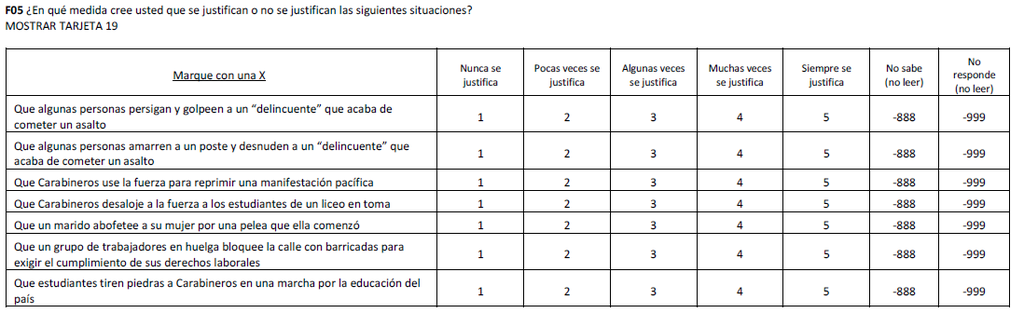